# Day 5 - building workflows

# Day 5 - building workflows

Today we’re going to learn about applying these R skills to repeat, reproduce, extend, and share your analyses.

First, let’s review the last two days.

- What have we done?
- How do we do it many times?
- Crack open your code - can you use it again?
- Can you adapt it to modify your question, feed in new data, and modify the scientifically-important bits easily?
- Can you share it with someone and they follow along?

Our goals are to learn how to:

- read lots of files, and different kinds of delimited files
- use loops to do similar steps for many inputs
- obtain and use packages to user other people’s work
- how to get more help and documentation
- write code, and design workflows, while thinking about future readers/users
- design steps/chunks of work as modular functions to make adaptable workflows
- more fun tricks in generating Rmarkdown reports

## What is a workflow?

What does it take to do an analysis?

When you embark on some project, it’s helpful (but not necessary) to plan where you are going. It’s best to setup and keep track of factors like:

- What data am I analyzing? What format is it in, and is that going to change? Will there be a lot more of this data that I want to process in the future?
- What kind of analyses do I want to do? What major steps do I have in my process? *What work from others can I re-use and build upon?*
- What do I want to generate? What is the desired outcome, and for whom is this intended?

In the author’s experience, bioinformatic workflows often involve reading in big (or many) flat files, processing the data into a useful form, sometimes using extra packages to analyze the data, then generating plots and statistical summaries of what you found - usually in an Rmarkdown-generated report.

## Loops to read many files

Let’s work through an analysis of the size of “structural” viral proteins. We’ve done some of the work for you already, and would recommend that you always document where the data came from and how it was retrieved/processed:

> The NCBI Identital Protein Groups database was queried for “structural” with “Division” restricted to “Viruses” and “Source database” restricted to “UniProtKB/Swiss-Prot”. 243 results were retrieved as FASTA files and converted using BASH commands into separate tab-delimited files. [^1]

These files are in the `data/viral_structural_proteins` folder, are tab-delimited three fields, and look like this:

```
Q8V433.1 Membrane protein       Bovine respiratory coronavirus (strain 98TXSF-110-LUN)  MSSVTTPAPVYTWTA...
```

How do you inspect these files? What BASH tools do you use?

### Reading in one file

Let’s read one of them into R.

The records are “delimited” by tabs, so tab-separated. We’ll need to use `read.delim`, specify a tab separator, and ignore the lack of a header. How do we do this?

#### Review of looking up documentation

You can look up the documentation for any named function or package by using the `?function` syntax.

Sometimes, you need to use extra backticks to make it work, like “?`+`”

If you don’t know what you’re looking for, you can search with `??`. Extra backticks don’t hurt, and help when you have spaces in the query.

#### Back to the file-reading

What does `?read.delim` say to do?

```r
viral_protein_data <- read.delim("data/viral_structural_proteins/viral_proteins_100.tsv",
    sep="\t",header=F)
viral_protein_data
```

```
##                           V1
## 1 Q8V433.1 Membrane protein
##                                                       V2
## 1 Bovine respiratory coronavirus (strain 98TXSF-110-LUN)
##                                                                                                                                                                                                                                       V3
## 1 MSSVTTPAPVYTWTADEAIKFLKEWNFSLGIILLFITVILQFGYTSRSMFVYVIKMIILW…
```

- How do we find the column names?
- What are two ways to access the protein sequence?
- How do we calculate the number of characters in this sequence? Try searching with “??`number of characters`”

### Doing things multiple times

You will want to do the same thing multiple times - automation is great. Let’s code up a simple little analysis - we’ll calculate the length (number of amino acids) in a viral structural protein sequence.

Let’s do this for all the proteins. The simplest way of doing this is to copy and paste it.

```r
viral_protein_data <- read.delim("data/viral_structural_proteins/viral_proteins_002.tsv",
      sep="\t",header=F, as.is=T)
nchar(viral_protein_data$V3[[1]])
```

```
## [1] 177
```

```r
viral_protein_data <- read.delim("data/viral_structural_proteins/viral_proteins_003.tsv",
      sep="\t",header=F, as.is=T)
nchar(viral_protein_data[1,"V3"])
```

```
## [1] 137
```

… just kidding.

Try this to, well, list files:

```r
list.files(path="data/viral_structural_proteins")[1:5]
```

```
## [1] "viral_proteins_000.tsv" "viral_proteins_001.tsv" "viral_proteins_002.tsv"
## [4] "viral_proteins_003.tsv" "viral_proteins_004.tsv"
```

Note that I put a `[1:5]` to limit it to the first 5. You could also use `head()`. It’s a good idea to work with a small subset of files while you are iterating through development, then scale it up to the entirety.

Now how do you calculate the number of characters for each protein?

How do we do this for every file listed … ?

### Loops

Loops are for running a “code block” as many times as the “condition” determines.

- A “code block” is either one line of code, or multiple lines of code surrounded by curly brackets - {}

  ```
    {
        code <- "in a block"
        with <- "multiple lines"
    }
  ```

- A “condition” is an expression of code that can either evaluate to either `TRUE` or `FALSE`, or set a variable for each time running the code block.

The most common form of this is a `for` loop. Other “control statements” or “flow control statements” are `while`, `repeat`, and `if`.

Let’s look up what they do, with “?`for`” Note the back ticks! These are a trick in R to make anything be interpreted as literally what you type, and not any special characters. Like “?`+`”, or “?`?`”

Here’s an example loop:

```r
for (i in 1:4) {
  print(i)
}
```

```
## [1] 1
## [1] 2
## [1] 3
## [1] 4
```

The pieces:

- `(i in 1:4)` is what is being looped over - `1:4` is a vector of 1 through 4 that is created, and it is put one at a time into `i` (a new variable). You need the parentheses.
- `{` and `}` denote the opening and closing brackets, specify the “code block” that is run each time.
- inside this “code block” is `print(i)` - it prints the variable `i`, which is set to a value of 1, 2, 3, or 4 for each loop

How do we loop through and print each file name?

What are the (1) code block and (2) loop condition ?

```r
for (i in list.files(path="data/viral_structural_proteins")[1:5] ) {
  print(i)
}
```

```
## [1] "viral_proteins_000.tsv"
## [1] "viral_proteins_001.tsv"
## [1] "viral_proteins_002.tsv"
## [1] "viral_proteins_003.tsv"
## [1] "viral_proteins_004.tsv"
```

How do we modify this to calculate the protein length?

```r
for (i in list.files(path="data/viral_structural_proteins")[1:5] ) {
  print(i)
  print(nchar(read.delim(i)$V3[[1]]))
}
```

```
## [1] "viral_proteins_000.tsv"
```

```
## Error in file(file, "rt"): cannot open the connection
```

Debugging…

```r
for (i in list.files(path="data/viral_structural_proteins",
                     full.names=T)[1:5] ) {
  print(nchar(read.delim(i,sep="\t",header=F,as.is=T)$V3[[1]]))
}
```

```
## [1] 1248
## [1] 1254
## [1] 177
## [1] 137
## [1] 117
```

#### Storing values from a loop

How do we store this value?

In other languages, “append”. But R is not built that way. It’ll work, but it’s very inefficient. The “R-way” to store values from a loop is to define a vector of the right length, then put each element in it.

```r
vector("character",10)
```

```
##  [1] "" "" "" "" "" "" "" "" "" ""
```

```r
vector(mode="numeric",length=5)
```

```
## [1] 0 0 0 0 0
```

```r
vector("logical",2)
```

```
## [1] FALSE FALSE
```

Okay, but how do we access each position to save the value? We need to turn out list of files into indicies. We’ll save it first so we can count how many there are.

`seq_along` is handy function, otherwise use something like `seq(1,length(x))`.

```r
first_five <- list.files(path="data/viral_structural_proteins")[1:5]
for (i in seq_along(first_five) ) {
  print(first_five[i])
}
```

```
## [1] "viral_proteins_000.tsv"
## [1] "viral_proteins_001.tsv"
## [1] "viral_proteins_002.tsv"
## [1] "viral_proteins_003.tsv"
## [1] "viral_proteins_004.tsv"
```

Putting these together, we can save a vector of file names:

```r
first_five <- list.files(path="data/viral_structural_proteins")[1:5]
filenamez <- vector("character",length(first_five))

for (i in seq_along(first_five) ) {
  filenamez[i] <- first_five[i]
}

filenamez
```

```
## [1] "viral_proteins_000.tsv" "viral_proteins_001.tsv" "viral_proteins_002.tsv"
## [4] "viral_proteins_003.tsv" "viral_proteins_004.tsv"
```

And finally calculate the length of each protein:

```r
first_five <- list.files(path="data/viral_structural_proteins",
                         full.names=T, pattern=".*tsv")[1:5]
lengthz <- vector("character",length(first_five))

for (i in seq_along(first_five) ) {
  lengthz[i] <- nchar( read.delim(first_five[i],
      header=F,as.is=T,sep="\t")$V3[[1]]
    )
}

lengthz
```

```
## [1] "1248" "1254" "177"  "137"  "117"
```

Now we can take off the `[1:5]` limiter, and do the whole set:

```r
first_five <- list.files(path="data/viral_structural_proteins",
                         full.names=T, pattern=".*tsv")
lengthz <- vector("character",length(first_five))

for (i in seq_along(first_five) ) {
  lengthz[i] <- nchar( read.delim(first_five[i],
      header=F,as.is=T,sep="\t")$V3[[1]]
    )
}
```

How do we go about visualizing/analyzing this?

```r
hist(lengthz)
```

```
## Error in hist.default(lengthz): 'x' must be numeric
```

er what…?

Numeric….

```r
first_five <- list.files(path="data/viral_structural_proteins",
                         full.names=T, pattern=".*tsv")
lengthz <- vector("numeric",length(first_five))

for (i in seq_along(first_five) ) {
  lengthz[i] <- nchar( read.delim(first_five[i],
      header=F,as.is=T,sep="\t")$V3[[1]]
    )
}
```

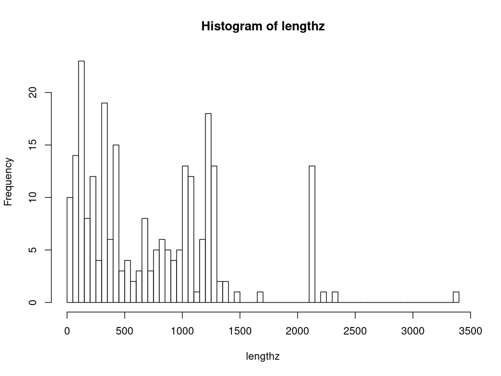

```r
hist(lengthz,breaks=50)
```

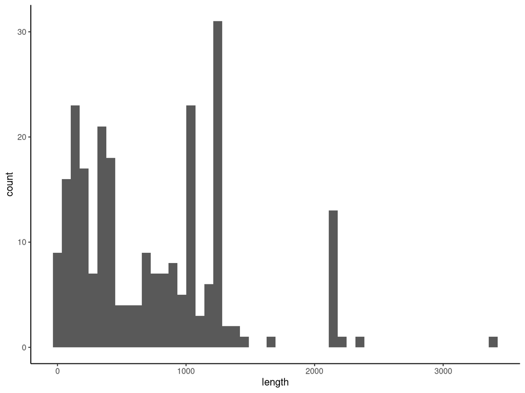

```r
library(ggplot2)
ggplot( data.frame(length=lengthz) )+theme_classic()+
  aes(x=length)+geom_histogram(bins=50)
```

```r
summary(lengthz)
```

```
##    Min. 1st Qu.  Median    Mean 3rd Qu.    Max.
##     0.0   230.0   626.0   726.3  1088.5  3390.0
```

## Writing (re)usable code

- Crack open your code - can you use it again?
- Can you adapt it to modify your question, feed in new data, and modify the scientifically-important bits easily?

#### Examples

Let’s look at two chunks of code from [a paper](https://github.com/sashaflevy/PPiSeq) (lightly edited). The experiment is counting barcoded lineages of yeast cells to estimate “PPIs” (protein-protein interactions) [^2]

Here’s an example of one style of writing R script:

```r
# filter out bad barcode lineages ( <= 2 time points counts > 0, or maximum of each time point <= 5 or total counts of a lineage < 10)
bad_index = rep(0, nrow(DBC_known_counts))
for(i in 1:length(bad_index)){
        counts = as.numeric(DBC_known_counts[i, 4:8])
        if (length(which(counts != 0)) < 3 | max(counts) < 5 | sum(counts) < 10){
                bad_index[i] = 1
        }
}
length(which(bad_index == 1)) # 1447775
```

- What is going on here?
- How do you feed in new data?
- How do you run this multiple times?
- How do you change the logic?

Here’s another example from the same author:

```r
H202_Output <- PPI_calling_sigmoid(
    PPI_multiple=dataFrameReader_T("/Volumes/zmliu_02/PPiseq_03/H2O2/counts/PPI_multiple_p.values.csv"),
    specific_PPV=c(seq(0.5,0.58,by=0.02),seq(0.6,0.8,by=0.01),seq(0.82,0.9,by=0.02)),
    Fitness=fitness(0,1,0.01),
    p_value=seq(-4,0,0.1),
    Neg_number_PPI=6e4,
    Neg_ref_number=50,
    p_threshold=-4
    p_loc=6,
)
```

Same questions.

What are some differences?

What’s useful for you?

What’s a lot of effort to do?

### Style guides can be inspiring

- [tidyverse style guide](https://style.tidyverse.org/)
- [google-specific changes](https://google.github.io/styleguide/Rguide.html)
- [Jean Fan’s](https://jef.works/R-style-guide/)
- search for “R style guide”

What style should you use?

Be inconsistently consistent! Balance for yourself:

- How easy is it to write?
- How easy is it for you to read?
- How easy is it for others to read?
- How similar is it to what everyone else is doing (a very good thing)?

But most importantly, use what folks around you are using. Be lazy, imitate others!

- How would you describe your code writing style?
- How do you name things?
- How good are your comments?
- What ideas would you like to incorporate?

## Functions as modular steps

Functions are handy. For example, let’s calculate the standard error of a sample of values:

```r
values <- c(4,3,2,2,5,3,6,2,2,4)
stderr(values)
```

```
## Error in stderr(values): unused argument (values)
```

Er … what? What does `stderr` do?

`?stderr`

How do you calculate the standard error of the mean of a sample?

```r
sd(values)/sqrt(length(values))
```

```
## [1] 0.4484541
```

Do we want to type this each time, copy and paste the code each time?

```r
values2 <- c(10,30,20)
sd(values2)/sqrt(length(values))
```

```
## [1] 3.162278
```

This can lead to errors in writing, small incorrect parts. It also leaves all the complexity to the reader, so it makes it harder to understand when reading code - hard to notice small details.

Where do we save it, how do we share it?

Copy and pasting from a file is okay, but it takes up a lot more work/space. We could email around a file of code chunks, or share on github.

How do we make sure it works?

This is hard to do with copy-paste code chunks. Changing the chunk to work on a new input can be an opportunity for introducing errors, typos.

#### Write it as a function!

What are the parameters? Are any defaults set? What does it return?

These can be copy and pasted, or `source()`’d from a `.R` file. Once you run it, you can test it and change inputs easily. Later, you could change the function and keep the same script of using the function.

```r
sez <- function(x) {sd(x)/sqrt(length(x))}
sez(values)
```

```
## [1] 0.4484541
```

```r
sez(rnorm(10))
```

```
## [1] 0.2867031
```

```r
sez(rnorm(100))
```

```
## [1] 0.08674793
```

```r
sez(rpois(1e3,3))
```

```
## [1] 0.05474995
```

### Using functions to write modular code

How might you carry out the workflow from the previous work to calculate protein sequence lengths?

One way is to flatten out all the tasks, and to script each individual task each time. This requires the author, user, and reader to understand a lot of complexity.

Another way to approach this is to cluster them into a hierarchy of modules.

In this organization, the analyst can operate at levels of steps, modules, and specific instructions, depending on what is needed.

### Tips for modular workflows

- Try to not “hardcode” things - if it’s a number, consider if it can be a *parameter* that is “passed in” as an argument.
- Group repeated code functions - some folks say you should never repeat code (but do what works for you!).
- Try to read inputs and outputs as general, flexible formats - strings of filenames, vectors of values
- Write a comment at the top of the function that says what it’s doing and what to expect, generally comment things.

Consider, the `list.files()` and `hist()` functions are already built this way! How about a `ggplot2` style boxplot?

#### Let’s write a plotting module/function

Write a function that makes a ggplot2 boxplot for some numbers.

What should the function take, what should it do?

What is “some numbers”?

What should it return?

```
wrap it in `print(ggplot code)` or return the ggplot object as
a variable
```

### More complex workflow

Let’s write a simulation of viral evolution.

(could be a bad idea, considering….)

lineage G1312F

exercise - wrap the entire analysis as a function

talk about ease of calling

ease of tweaking this

exercise - break into subfunctions, generate and plot

ease of changing models

### Apply is a popular tool

Apply is another common way of doing something over and over. It is a very compact way to take pieces of a list, vector, dataframe, or matrix and put them into a function. There are:

- `apply` - for 2D objects
- `lapply` - for lists and vectors
- `sapply` - is `lapply` but with simplified returns
- `mapply` - is for combinations of multiple variables
- `replicate` - calls a function multiple times

Some people *strongly* prefer coding this way. Here is an example:

```r
list_of_protein_files <- lapply(
        list.files("data/viral_structural_proteins/",full.names=T),
        read.delim,
        sep="\t",header=F)
```

These “apply” some “FUN” to some input variables, by taking each element or slices of elements from input variables and putting them in as arguments to the function being applied. They return odd things, often lists (`unlist()`).

## Packages - install and use

Let’s take a look at your code from the last few days. How would you share this with the other people in the course?

R, like other languages, is built on a package system - if you wrap up your code in particular expected ways and put it in particular expected places, it is very easy for others to get and use your code

Packages are [said to be easy to make](https://ourcodingclub.github.io/tutorials/writing-r-package/), [from scratch](https://hilaryparker.com/2014/04/29/writing-an-r-package-from-scratch/). There’s more [comprehensive instruction here](https://r-pkgs.org/). Personally, the author has never had cause to make one, but I can report that they’re very easy to use!

### CRAN is the canonical R package resource

The Comprehensive R Archive Netowrk [CRAN](https://cran.r-project.org/web/packages/) is an integral part of the R environment. This is a global and free resource for storing and distributing code as R packages - well documented and designed chunks of code.

You can install packages using the RStudio IDE, but it’s most important to know how to do it in R - what’s happening just under the hood.

Use `library` to load packages. You should be able to load a package you’ve already installed. Call `library()` function, with an argument of the library name, as a string.

Try loading this one:

```r
library("stringdist")
library(stringdist)
```

Don’t have it? You can look for packages by using a search engine, or finding suggestions in the documentation, papers. Once you have a package name, use

```r
install.packages("stringdist")
```

to install it. You may need to select a “mirror”. This is just where you are downloading from, usually just go with “0-Cloud” [^3].

- get the stringdist library, use it
- get a new viz layer, use it

### Using packages without `library()`-ing them

Some packages you don’t really want to have to go through the trouble of loading, you’ll just want one function. For example, this website is generated with one function, `render_book()` in the package `bookdown`. Instead of:

```r
library(bookdown)
render_book()
```

I can save a line by just using `::`

```r
bookdown::render_book()
```

This means I am looking in library `bookdown` for function `render_book`. The function is hidden again right afterwards, but it is useful if you just want to run one function from a library, once.

### Github is a common place for sharing packges in development

Installing from github requires some different programming - and there’s libraries with functions for this.

```r
library("remotes")
```

This used to be part of the `devtools` package, but the authors have been “uncoupling” these to make each package simple and composable.

#### Let’s install a package off of github.

Here’s a cool [Ghibli color palette](https://github.com/ewenme/ghibli), so you can change sets of colors for your plots. Try installing it with:

```r
remotes::install_github("ewenme/ghibli")
```

Then adapt one of your previous plots (that has colors) to use these new color palettes.

Exercise - install a package from github and learn how to use it

- [Sports field plotting](https://github.com/rossdrucker/sportyR)
- [Ridgeplots in ggplot2](https://github.com/wilkelab/ggridges)

problems with this - security, eh

### Bioconductor is a great place for bio-related packages 😬

Bioconductor is a giant repository of just scientific, well bio-focused, packages. It’s where a lot of bioinformatics software gets published. However, it has it’s own package system and thus package manager. You will have to install it … from CRAN. Like so:

```r
install.packages("BiocManager")
```

If you’re recall from before, we can use `::` to avoid having to actually `library` the whole package:

```r
BiocManager::install()
```

How to install Bioconductor

Scholars will know how to install Bioconductor package from CRAN

Scholars will know how to find and install packages from Bioconductor

As demo, install DESeq2 and start to work through a tutorial with one of their datasets.

### What packages do you have already?

explore the namespace for a package, ie ?packagename:: and TAB or ?packagename::

how to print out all the packages you have loaded

### Finding more help and documentation

```r
?geom_line
```

```r
?stringdist
```

Source up problems from the class?

Demo a weird plot idea, search for how to do it on stack overflow?

Maybe how to change the color of facet labels in a ggplot facet graph, that’s a bit tricky and demonstrates why base R is important…

## More `rmarkdown` for reproducibile sharing

How are you saving your notes for this class?

How do you usually save notes/code/instructions?

How do you share this with others?

### rmarkdown package

#### Background

The `rmarkdown` package was created by [Yihui Xie](https://www.rstudio.com/speakers/yihui-xie/), extending from previous work and ideas in `knitr` and `sweave`.

It’s a way of mixing writing with code, such that you can run the code and it makes a pretty doc (and [more](https://rmarkdown.rstudio.com/gallery.html)).

#### Chunk options

You can set chunk-level options in an Rmd, for each code chunk. Such as:

[output not shown]

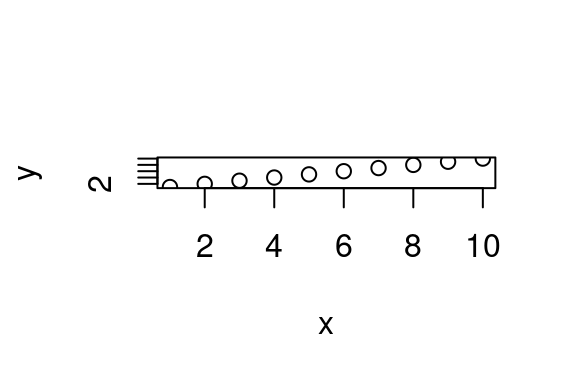

```r
x <- 1:10
y <- 1:10
plot(x,y)
```

It is possible to enable figure captions.

#### Document options

You can set document-level options to. To do this, you create what’s called a YAML header, like so:

```
---
title: "Titled"
author: "yours"
---
```

```
---
title: "Titled"
author: "yours"

---
```

#### How it works, sort of…

`rmarkdown` parses an Rmd file to extract out the R code. It runs this, using the chunk and other options to control this, then makes outputs from different chunks (text and plots). It then sticks the text and images into a `markdown` document, and uses a program called `pandoc` (included inside Rstudio) to turn that into HTML, PDF, and/or slides.

### Sharing with others

What does someone need to re-run your analyses?

- R (often Rstudio)
- what packages you’re using

why the hell we want others to use our code? Well I’ll tell you why - the general intellect

think about this

think about the next person coming along, or yourself in 3 months

links on syllabus for more info

all sorts of automated stuff you can do

### Reproducibility and sharing

think about this

think about the next person coming along, or yourself in 3 months

links on syllabus for more info

all sorts of automated stuff you can do

## Troubleshooting, getting help, dissecting problems

You will have problems.

How do you (1) get past these and (2) learn from them?

What kinds of errors did we encounter in this class?

How do we deal with these?

### Places to look for help

- yourself - past notes, troubleshoot logically
- the people around you, research mentors
- Slack channel
- github/gitlab “Issues” page - search first the closed issues!!!
- StackOverflow - search first for similar problems!!!
- twitter (for fun problems)

It helps to have a…

### Minimum reproducible example

If you can’t find an easy answer, it is important to begin to approach the problem like you would a science problem.

Reduce the problem, eliminate extraneous variables.

Use or capture intermediate steps to identify where the issue is.

Collect `sessionInfo()` and share it with folks.

## Conclusion

Today we covered:

- loops to repeat code
- aspects of nice (re)usable code
- writing code modularly with functions
- finding and using packages
- writing an Rmarkdown report
- finding help and tackling a complex problem

We hope you are better oriented and prepared to repeat your analyses to build a complete story, reproduce these larger analyses workflows, extend from your work to do more complicated workflows, and share your analyses with others in a well-organized but complete way.

You can extend on these ideas. Here’s a couple of areas that might be useful:

**Workflow / pipeline tools**

These are automation tools to smartly run different chunks of analyses. This is really handy when parts of your workflow take a long time, and you usually don’t want to be  
re-running those, but you do want it to be able to run the whole thing automatically.

You can use old-school shell-like tools such as “[Make/Makefiles](https://makefiletutorial.com/)”, newfangled but complex tools like “Nextflow” or “snakemake”, or R-specific tooks like “[targets](https://books.ropensci.org/targets/walkthrough.html)”.

[^1]: One crucial aspect missing is the actual BASH commands used. I did not save them as a script, and I *should* go back, save them in a script, and re-run that to make sure I get the same result!
[^2]: Ask Darach if you want details, or read the paper
[^3]: I have no idea where this is, never heard of that country!